# F9_00_EXEMPT_STAT_4947A1_X

4947(a)(1) organization [x] · Checkbox report

## Overview

**Description**

Indicates a 4947(a)(1) organization

**Table**

`F9-P00-T00-HEADER` (one)

**Location code**

`F990-PC-PART-00-SECTION-I`, `F990-EZ-PART-00-SECTION-J`

**Family**

`F990-PC-PART-00-SECTION-I` · siblings: F9_00_EXEMPT_STAT_501C_X, F9_00_EXEMPT_STAT_501C3_X, F9_00_EXEMPT_STAT_527_X

**Data type**

checkbox (xsd: , CheckboxType)

**Scope**

HD

**Status**

unreviewed

5

xpaths mapped (4 observed)

3,398

filings with a value

2009–2024

tax years observed

4

open flags (2 errors)

## Flags

| Severity | Flag | Xpath | Detail |
| --- | --- | --- | --- |
| ⚠ error | `POLARITY` | IRS990/Organization4947a1NotPFInd | negated element ‘Organization4947a1NotPFInd’ pooled with non-negated xpaths |
| ⚠ error | `POLARITY` | IRS990EZ/Organization4947a1NotPFInd | negated element ‘Organization4947a1NotPFInd’ pooled with non-negated xpaths |
| ▲ warn | `INCIDENCE_BREAK` |  | 990 fill rate changes up to 12.1x year-on-year (in 2010) |
| ⓘ info | `UNOBSERVED` | IRS990/Form990PartI/Organization4947a1 | never observed in TY2009-2024 filings |

## Xpaths

All mapped xpaths (under /Return/ReturnData or /Return/ReturnHeader), oldest first. Charts label each series by its xpath.

| Xpath | Form | First year | Last year | Versions | Filings | Repeats in |
| --- | --- | --- | --- | --- | --- | --- |
| IRS990/Organization4947a1 | 990 | 2009 | 2012 | 10 | 737 | 0.0% |
| IRS990EZ/Organization4947a1 | 990-EZ | 2009 | 2012 | 10 | 123 | 0.0% |
| IRS990/Organization4947a1NotPFInd | 990 | 2013 | 2024 | 35 | 1,948 | 0.0% |
| IRS990EZ/Organization4947a1NotPFInd | 990-EZ | 2013 | 2024 | 33 | 590 | 0.0% |
| IRS990/Form990PartI/Organization4947a1 | 990 |  |  |  | 0 |  |

## Coverage

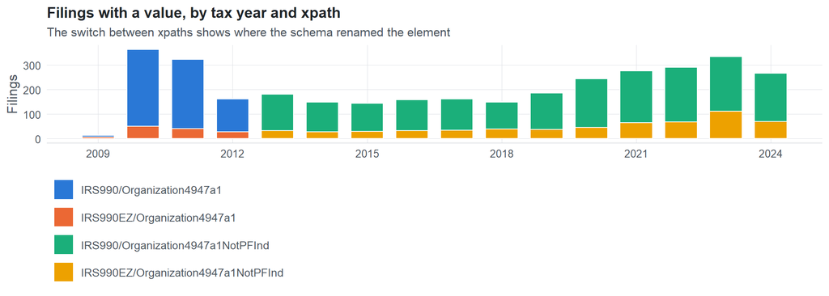

**Table view**

Table view: filings by tax year and series

| Tax year | IRS990/Organization4947a1 | IRS990EZ/Organization4947a1 | IRS990/Organization4947a1NotPFInd | IRS990EZ/Organization4947a1NotPFInd |
| --- | --- | --- | --- | --- |
| 2009 | 7 | 6 | 0 | 0 |
| 2010 | 313 | 50 | 0 | 0 |
| 2011 | 282 | 40 | 0 | 0 |
| 2012 | 135 | 27 | 0 | 0 |
| 2013 | 0 | 0 | 149 | 32 |
| 2014 | 0 | 0 | 121 | 28 |
| 2015 | 0 | 0 | 115 | 29 |
| 2016 | 0 | 0 | 125 | 33 |
| 2017 | 0 | 0 | 127 | 34 |
| 2018 | 0 | 0 | 110 | 39 |
| 2019 | 0 | 0 | 148 | 37 |
| 2020 | 0 | 0 | 199 | 45 |
| 2021 | 0 | 0 | 212 | 64 |
| 2022 | 0 | 0 | 223 | 68 |
| 2023 | 0 | 0 | 223 | 111 |
| 2024 | 0 | 0 | 196 | 70 |

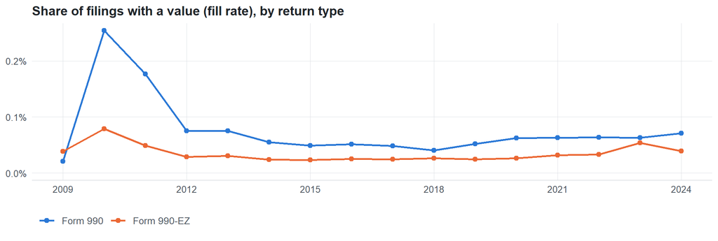

**Table view**

Table view: fill rate

| Tax year | Return type | Filings | All filings | Fill rate |
| --- | --- | --- | --- | --- |
| 2009 | Form 990 | 7 | 33,311 | 0.02% |
| 2009 | Form 990-EZ | 6 | 15,470 | 0.04% |
| 2010 | Form 990 | 313 | 123,025 | 0.25% |
| 2010 | Form 990-EZ | 50 | 63,326 | 0.08% |
| 2011 | Form 990 | 282 | 159,504 | 0.18% |
| 2011 | Form 990-EZ | 40 | 82,048 | 0.05% |
| 2012 | Form 990 | 135 | 179,688 | 0.08% |
| 2012 | Form 990-EZ | 27 | 93,750 | 0.03% |
| 2013 | Form 990 | 149 | 198,855 | 0.07% |
| 2013 | Form 990-EZ | 32 | 104,375 | 0.03% |
| 2014 | Form 990 | 121 | 218,619 | 0.06% |
| 2014 | Form 990-EZ | 28 | 116,417 | 0.02% |
| 2015 | Form 990 | 115 | 233,519 | 0.05% |
| 2015 | Form 990-EZ | 29 | 124,894 | 0.02% |
| 2016 | Form 990 | 125 | 243,903 | 0.05% |
| 2016 | Form 990-EZ | 33 | 130,484 | 0.03% |
| 2017 | Form 990 | 127 | 261,612 | 0.05% |
| 2017 | Form 990-EZ | 34 | 139,144 | 0.02% |
| 2018 | Form 990 | 110 | 271,442 | 0.04% |
| 2018 | Form 990-EZ | 39 | 149,384 | 0.03% |
| 2019 | Form 990 | 148 | 283,694 | 0.05% |
| 2019 | Form 990-EZ | 37 | 152,622 | 0.02% |
| 2020 | Form 990 | 199 | 320,342 | 0.06% |
| 2020 | Form 990-EZ | 45 | 169,864 | 0.03% |
| 2021 | Form 990 | 212 | 336,480 | 0.06% |
| 2021 | Form 990-EZ | 64 | 202,724 | 0.03% |
| 2022 | Form 990 | 223 | 349,055 | 0.06% |
| 2022 | Form 990-EZ | 68 | 206,130 | 0.03% |
| 2023 | Form 990 | 223 | 354,768 | 0.06% |
| 2023 | Form 990-EZ | 111 | 206,379 | 0.05% |
| 2024 | Form 990 | 196 | 277,298 | 0.07% |
| 2024 | Form 990-EZ | 70 | 178,867 | 0.04% |

## Values

| Result | Check | Detail |
| --- | --- | --- |
| ✓ pass | Values are checkbox codes | 100.0% of values are X / true / false / 1 / 0 |
| ⓘ info | Meaning of a blank | values are almost always X/true when present, so a missing value usually means unchecked |
| ⚠ fail | Element names agree in polarity | negated: Organization4947a1NotPFInd \| not negated: Organization4947a1 |

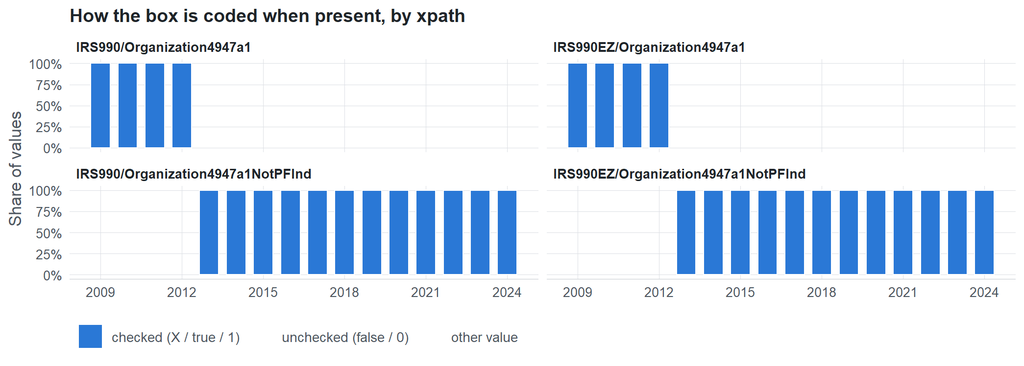

**Table view**

Table view: value coding by tax year

| Series | Tax year | Code | Filings | Share |
| --- | --- | --- | --- | --- |
| IRS990/Organization4947a1 | 2009 | checked (X / true / 1) | 7 | 100.0% |
| IRS990/Organization4947a1 | 2010 | checked (X / true / 1) | 313 | 100.0% |
| IRS990/Organization4947a1 | 2011 | checked (X / true / 1) | 282 | 100.0% |
| IRS990/Organization4947a1 | 2012 | checked (X / true / 1) | 135 | 100.0% |
| IRS990EZ/Organization4947a1 | 2009 | checked (X / true / 1) | 6 | 100.0% |
| IRS990EZ/Organization4947a1 | 2010 | checked (X / true / 1) | 50 | 100.0% |
| IRS990EZ/Organization4947a1 | 2011 | checked (X / true / 1) | 40 | 100.0% |
| IRS990EZ/Organization4947a1 | 2012 | checked (X / true / 1) | 27 | 100.0% |
| IRS990/Organization4947a1NotPFInd | 2013 | checked (X / true / 1) | 149 | 100.0% |
| IRS990/Organization4947a1NotPFInd | 2014 | checked (X / true / 1) | 121 | 100.0% |
| IRS990/Organization4947a1NotPFInd | 2015 | checked (X / true / 1) | 115 | 100.0% |
| IRS990/Organization4947a1NotPFInd | 2016 | checked (X / true / 1) | 125 | 100.0% |
| IRS990/Organization4947a1NotPFInd | 2017 | checked (X / true / 1) | 127 | 100.0% |
| IRS990/Organization4947a1NotPFInd | 2018 | checked (X / true / 1) | 110 | 100.0% |
| IRS990/Organization4947a1NotPFInd | 2019 | checked (X / true / 1) | 148 | 100.0% |
| IRS990/Organization4947a1NotPFInd | 2020 | checked (X / true / 1) | 199 | 100.0% |
| IRS990/Organization4947a1NotPFInd | 2021 | checked (X / true / 1) | 212 | 100.0% |
| IRS990/Organization4947a1NotPFInd | 2022 | checked (X / true / 1) | 223 | 100.0% |
| IRS990/Organization4947a1NotPFInd | 2023 | checked (X / true / 1) | 223 | 100.0% |
| IRS990/Organization4947a1NotPFInd | 2024 | checked (X / true / 1) | 196 | 100.0% |
| IRS990EZ/Organization4947a1NotPFInd | 2013 | checked (X / true / 1) | 32 | 100.0% |
| IRS990EZ/Organization4947a1NotPFInd | 2014 | checked (X / true / 1) | 28 | 100.0% |
| IRS990EZ/Organization4947a1NotPFInd | 2015 | checked (X / true / 1) | 29 | 100.0% |
| IRS990EZ/Organization4947a1NotPFInd | 2016 | checked (X / true / 1) | 33 | 100.0% |
| IRS990EZ/Organization4947a1NotPFInd | 2017 | checked (X / true / 1) | 34 | 100.0% |
| IRS990EZ/Organization4947a1NotPFInd | 2018 | checked (X / true / 1) | 39 | 100.0% |
| IRS990EZ/Organization4947a1NotPFInd | 2019 | checked (X / true / 1) | 37 | 100.0% |
| IRS990EZ/Organization4947a1NotPFInd | 2020 | checked (X / true / 1) | 45 | 100.0% |
| IRS990EZ/Organization4947a1NotPFInd | 2021 | checked (X / true / 1) | 64 | 100.0% |
| IRS990EZ/Organization4947a1NotPFInd | 2022 | checked (X / true / 1) | 68 | 100.0% |
| IRS990EZ/Organization4947a1NotPFInd | 2023 | checked (X / true / 1) | 111 | 100.0% |
| IRS990EZ/Organization4947a1NotPFInd | 2024 | checked (X / true / 1) | 70 | 100.0% |

Raw values by xpath (all years)

| Series | Value | Filings |
| --- | --- | --- |
| IRS990/Organization4947a1 | X | 737 |
| IRS990EZ/Organization4947a1 | X | 123 |
| IRS990/Organization4947a1NotPFInd | X | 1,948 |
| IRS990EZ/Organization4947a1NotPFInd | X | 590 |

## Examples

| Tax year | Return | Xpath | Organization | Value | Source |
| --- | --- | --- | --- | --- | --- |
| 2024 | 990 | IRS990/Organization4947a1NotPFInd | COHEN MOE J FBO JEWISH FEDERATION | X | [XML](https://gt990datalake-rawdata.s3.amazonaws.com/EfileData/XmlFiles/202531119349300133_public.xml) |
| 2024 | 990EZ | IRS990EZ/Organization4947a1NotPFInd | PETER MICHAEL STELLATO CHARITY INC | X | [XML](https://gt990datalake-rawdata.s3.amazonaws.com/EfileData/XmlFiles/202520709349201852_public.xml) |
| 2023 | 990 | IRS990/Organization4947a1NotPFInd | WILLIAM T BARTLETT TUW TRUST DIVISION | X | [XML](https://gt990datalake-rawdata.s3.amazonaws.com/EfileData/XmlFiles/202421359349304732_public.xml) |
| 2023 | 990EZ | IRS990EZ/Organization4947a1NotPFInd | VICTORIAS HOPE INTERNATIONAL LTD | X | [XML](https://gt990datalake-rawdata.s3.amazonaws.com/EfileData/XmlFiles/202420619349200182_public.xml) |
| 2022 | 990 | IRS990/Organization4947a1NotPFInd | ROEBLING TUW FBO MORTON PLANT FDN (PRE 1 | X | [XML](https://gt990datalake-rawdata.s3.amazonaws.com/EfileData/XmlFiles/202331309349304208_public.xml) |
| 2022 | 990EZ | IRS990EZ/Organization4947a1NotPFInd | ANNA H DEHAVEN TRUST | X | [XML](https://gt990datalake-rawdata.s3.amazonaws.com/EfileData/XmlFiles/202410739349200506_public.xml) |
| 2021 | 990 | IRS990/Organization4947a1NotPFInd | COHEN MOE J FBO JEWISH FEDERATION | X | [XML](https://gt990datalake-rawdata.s3.amazonaws.com/EfileData/XmlFiles/202233149349304743_public.xml) |
| 2021 | 990EZ | IRS990EZ/Organization4947a1NotPFInd | BW BONELL IRREV TA FBO DIOCESE OF COLO | X | [XML](https://gt990datalake-rawdata.s3.amazonaws.com/EfileData/XmlFiles/202212929349201601_public.xml) |
| 2020 | 990 | IRS990/Organization4947a1NotPFInd | LULA E BOWMAN | X | [XML](https://gt990datalake-rawdata.s3.amazonaws.com/EfileData/XmlFiles/202221039349301717_public.xml) |
| 2020 | 990EZ | IRS990EZ/Organization4947a1NotPFInd | JOHN KOT CHARITABLE REMAINDER UNITRUST | X | [XML](https://gt990datalake-rawdata.s3.amazonaws.com/EfileData/XmlFiles/202102849349201060_public.xml) |
| 2019 | 990 | IRS990/Organization4947a1NotPFInd | WILBUR C GROSSE TRUST | X | [XML](https://gt990datalake-rawdata.s3.amazonaws.com/EfileData/XmlFiles/202021409349301732_public.xml) |
| 2019 | 990EZ | IRS990EZ/Organization4947a1NotPFInd | GOLDIE TUCKER TRUST | X | [XML](https://gt990datalake-rawdata.s3.amazonaws.com/EfileData/XmlFiles/202001979349203860_public.xml) |

## Reviewer checklist

- The definition matches the form line and instructions for every xpath’s schema years.
- Every xpath pooled here measures the same thing on the 990 and 990-EZ (close enough for analysis).
- The coverage chart has no unexplained gaps or jumps between tax years.
- Each open flag is fixed, or accepted with a note in validation_log.csv.
- The box means the same thing (and the same polarity) under every xpath: ‘required’ is never pooled with ‘not required’.
- Absent means unchecked for this line, or the question was skipped; the data dictionary says which.
- Yes/No questions coded as two separate boxes are mapped to one variable only when that is intended.

Record the review as a row in `inst/extdata/src/validation_log.csv` (variable_name, reviewer, date, status, note). Evidence built 2026-09-23 17:09:04 MST from the ef2 DuckDB builds (tax years 2009–2024).